# Behavioral and immunological responses

### Parasite infection alters host behavior

- Behavioral defense (e.g., grooming)
- Parasite manipulation (e.g., parasite-induced changes to host behavior)
- Sickness behavior (e.g., fever)

### Grooming

- Societal benefits
- Removal of ectoparasites
  - which can vector some rough parasites

> Humans groom, but what are other related activities that we do?

### Desert rodent grooming behavior and flea mortality

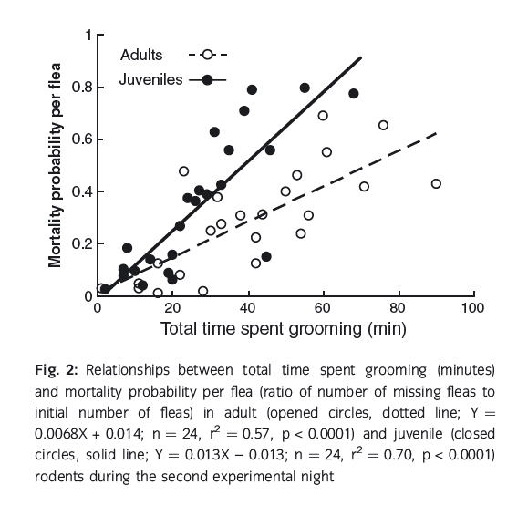

### Preening

Birds will use their beaks to reorient their feathers, clean plumage, and check for ectoparasites.

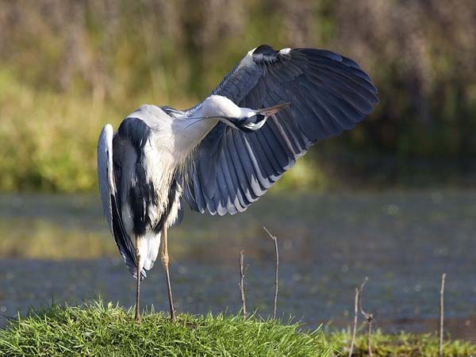

### Uropigeal gland

This gland contains oil that the birds use during preening, distributing it among their feathers.

- good for waterproofing
- anti-parasitic
- anti-bacterial

### Bird bill size influences ability to remove parasites

- Parasites specialize on certain host species.
- Lice specialize on birds they can parasitize.
- Tends to lead a relationship where bigger birds have bigger lice.

### Bigger host, bigger parasite

This is called “Harrison’s rule” and has mixed support.

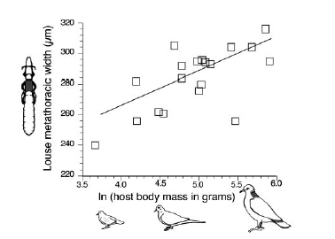

### What’s driving this?

- Differences in attachment rate? (no)
- Differences in feeding success? (no)
- Escaping from preening (yes)

### Medicinal plant use

Hosts will change their diet to combat parasites

[figure not shown]

### Monarchs and medicinal plant use (ish)

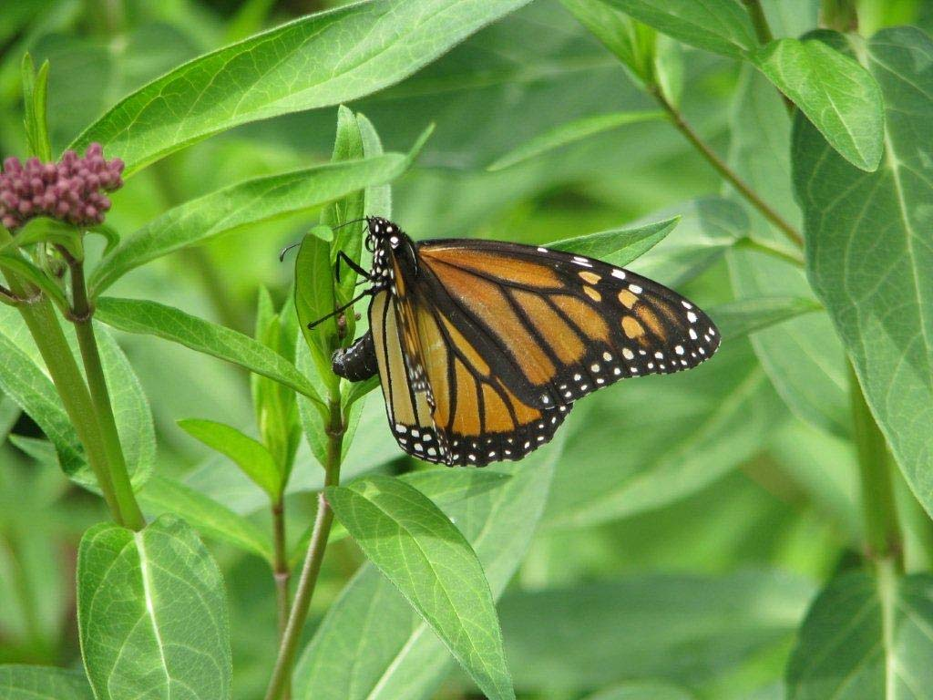

### (ish) because used for anti-predator and anti-parasite

- Monarch butterflies are a classic example
  - sequester cardenolides from milkweed plants
  - deters predators
  - reduces spore load of OE parasite

### If infected, preferentially lay eggs on toxic plant

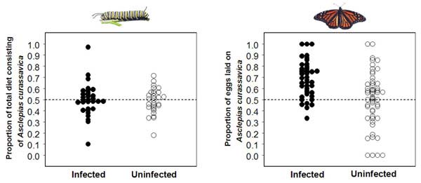

### Using the environment in your favor

- Hosts may preferentially occupy different environments to avoid parasite encounter or infection

### *Entomophthora muscae*, fungal pathogen of house flies

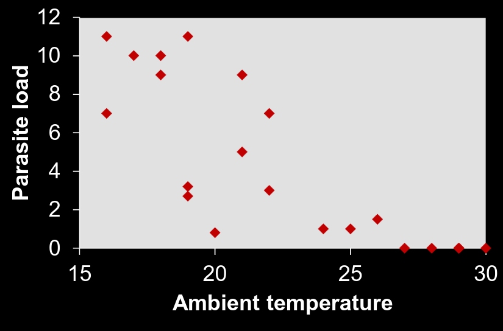

### Behavioral fever

- Flies can’t generate their own body heat to change internal temperature.
- If infected, prefer warmer environments

<sub>Kalsbeek et al. 2001. Biological control, 21:264-273.</sub>

### Behaviors to avoid encounter

> Just go where the parasites are not, right?

Typically manifests in two ways:

- uninfected individuals spending more time “away” from parasites
- uninfected individuals avoid infected individuals

### Host behavior responses to infection risk

- Parasite removal
- Grooming
- Medicinal plant use
- Behavioral fever
- Behavioral avoidance
  - Self-annointing / swatting
  - Seeking low-risk habitats
  - Avoid infected conspecifics

### Parasite manipulation of host behavior

Some behaviors predispose host to things that benefit the parasite

- increased growth rate of parasite inside host
- increased predation risk for trophically-transmitted parasite

> Let’s go through some cool examples of this

### *Cordyceps sp.* (fungi) in insect hosts

[video not shown]

### *Leucochloridium paradoxum* (trematode) infecting snails

[video not shown]

### *Myrmeconema neotropicum* (nematode) infecting ants

[video not shown]

### Host behavior can

- reduce parasite burden (e.g., grooming)
- enhance parasite burden (e.g., parasite manipulation)

### What types of parasites would benefit most from manipulating host behavior?

> And what parasites would really not want to directly manipulate host behavior?

### Sickness behaviors

- Typically include anorexia, fatigue, and reduction in social and reproductive activities
- Hypothesized to be adaptive changes for host
- Incidental though, as some of these behaviors are result of body fighting parasite

### Incidental changes in behavior

- Sleepiness results in reduced contact with others
  - could aid in recovery
  - but could also increase transmission of some parasites

> What hypothesis could we pose around the expression of sickness behaviors across parasite species?

### Decreased cognitive ability

- COVID brain fog (jk)
- *Bombus impatiens* infected by *Crithidia bombi* (protozoan)

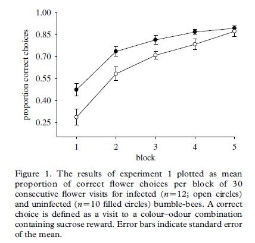

### Questions to think about

- When are sickness behaviors maladaptive to the parasite?
- What parts of the transmission process (encounter + susceptibility) do each of these behaviors (grooming, sickness, manipulation) affect?
- Where would self-medication of hosts fall in the continuum of resistance and tolerance tradeoffs?

## End of lecture 1

### Host immunological responses to infection

- Adaptive and innate immune defenses
  - *innate*: general non-specific response to anything (generally larger extracellular things)
  - *adaptive*: responds to specific antigens (targeted response)

### Innate immunity

- generalist immune response to any invader, including sensing wounds or trauma
- the immune system you are born with
- includes physical structures in the loosest definition (skin and mucous)
- activate general cells to attack invader and initate repair of damaged tissue

### Adaptive immunity

- *specficity*: ability to recognize and attack specific cell types.
- *memory*: ability to remember cells that have invaded previously
- *diversity*: ability to respond to wide range of invasive organisms
- *self-tolerance*: ability to recognize and not attack self (e.g., auto-immune disorders)

### Some jargon before we dive into adaptive immunity

*Antigen*

- each pathogen generates multiple *antigens*, or molecule that stimulates an immune response

*Antibodies*

- immune molecules that bind to antigens

### Major histocompatiability complex

- labels foreign bodies for immune system to decide ‘self’ or ‘not self’
- reason why skin grants and transplanted organs get rejected
- wide variation in MHC (2-3 people will share be close match out of every 100,000 people)

### The two branches of adaptive immunity

- Cell-mediated (intracellular)
- Humoral (extracellular)

### Cell-mediated

- necessary to destroy pathogens within host cells

- cytotoxic T-cells
  - bind and destroy infected host cells (also called “killer T-cells”)

### Humoral

- attacks pathogen outside of host cells
- produced by B-cells (lymphocytes) activated by T-helper cells (Th2 response)
- activated B-cells also produce memory cells
- bind to antigens to block active sites
- *agglutination*: clumping of immune cells around pathogens

### Major histocompatiability complex

Class 1: tagging intracellular pathogens

Class 2: tagging extracellular pathogens

### How effective is immune system at combating different types of parasites?

- complete removal and lasting immunity (classic microparasite response)
- partial control with longer-term persistence or reinfection (classic macroparasite)
- total failure to control pathogen (novel pathogens, immuncompromise)

### Multiple challenges and tradeoffs

- Co-infection (being infected by two or more parasites at the same time) can be bad
- Mounting a Th1 and Th2 response is demanding
- So challenges of a macroparasite and a microparasite might be worse off than two microparasites, right?

<sub>See work from Amy Pederson and Vanessa Ezenwa looking at some cool natural examples of coinfection</sub>

### Host resistance evolution

- Selective force is on the parasite to evolve ways to bypass host immune defenses
- Selective force is on the host to effectively respond to parasites

### Definition of host resistance

- ability to prevent or limit parasite infection (inverse of susceptibility)
- *‘resistant’*: rarely or never infected
- *susceptible*: commonly infected
- *tolerance*: perform well despite infection (in terms of survival/growth/reproduction)

### Note that resistant is differently defined than how we previously talked about

- A resistant host is rarely infected, but when we talk about resistance-tolerance tradeoffs, it is assumed that the parasite has infected the host, and the host can respond to this in at least two ways; resistance or tolerance

### Tolerance example

Low elevation birds had lower mortality and higher weight despite having higher parasitemia

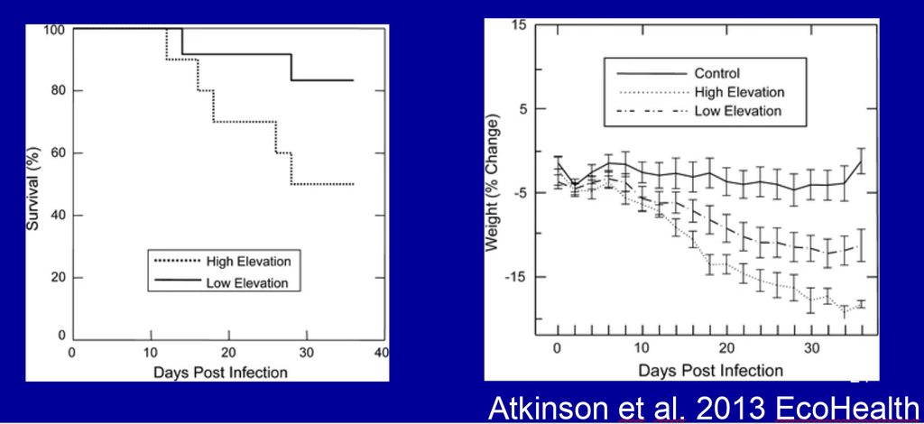

### resistance-tolerance tradeoffs

Imagine the host has a choice in how it can respond to a pathogen

> Does the host focus on fighting the negative effects of pathogen?

> Does the host focus on reducing damage of pathogen, allowing more focus on survival/growth/reproduction?

<sub>Not inherently a tradeoff, but often presented as such</sub>

### Parasite facilitation through host immune costs

One paper you read this week was from Ezenwa et al. *Am Nat*. This is a clear empirical demonstration of apparant facilitation between two coinfecting parasites (Tuberculosis and an intestinal helminth in African buffalo).

> Anybody want to summarize this paper for the class?

### Why don’t have more examples of evolution of host resistance?

Given strong selection, why don’t all hosts evolve resistance?

### Tasmanian devil facial tumor disease

Transmissible cancer affecting devils

> “Genetic impoverishment has made the immune system blind”

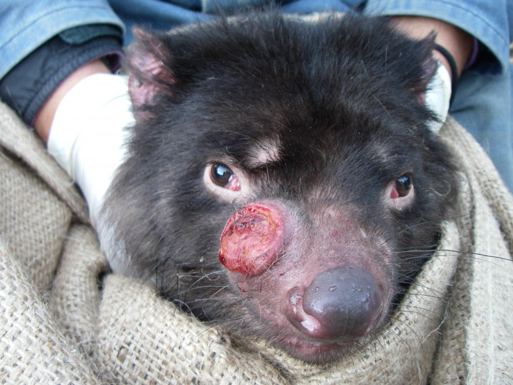

<sub>Siddle et al. 2007 *PNAS*</sub>

### Strain-specific immunity

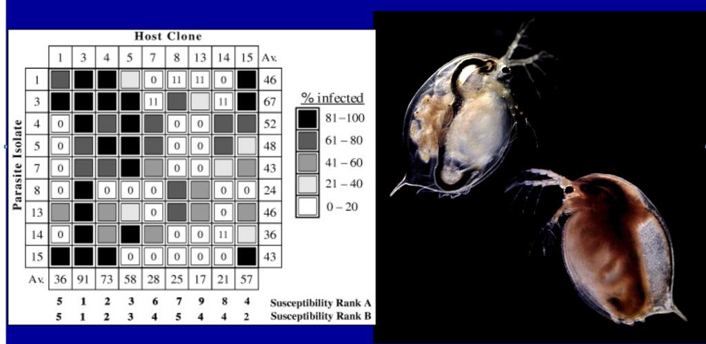

### Costs of resistance

- Traits that confer resistance could lower other fitness components
- Some good papers on when these should occur and if they are even *really* a thing.

Cost = S fitness - R fitness

<sub>reviewed in Burrington 2000; good critique from Lenormand et al. 2018 *Rethinking Ecology*</sub>

### What happens when we do see the evolution of host resistance?

We tend to see the co-evolution of the parasite.

*Red-queen dynamics*: co-evolutionary arms race between host and parasite.

### A snail example

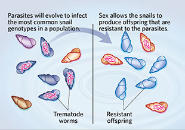